# AI Translator: convert raw country livestock data into the input template | Cattle GHG Uncertainty Calculator Help

[figure not shown]

[figure not shown]

[figure not shown]

## What the AI translator is for

The Cattle Uncertainty App expects its data in a specific Excel template, so that it can run the uncertainty analysis. Real national inventory data rarely arrives in that shape. Column names differ. Units differ. Sub-category labels reflect local practices.

The AI translator converts raw inventory data, in whatever shape it arrives, into the exact template the tool needs. This will save you a lot of time as converting your data to the right template would be very time consuming.

## Preparing your file

A file that meets these points usually needs three to five questions. A file that does not can need twelve, and more errors are possible.

## Step by step

### 1. Accessing the AI translator

In the Resources tab of the app, the first thing you see is that you have to sign in to use the translator.

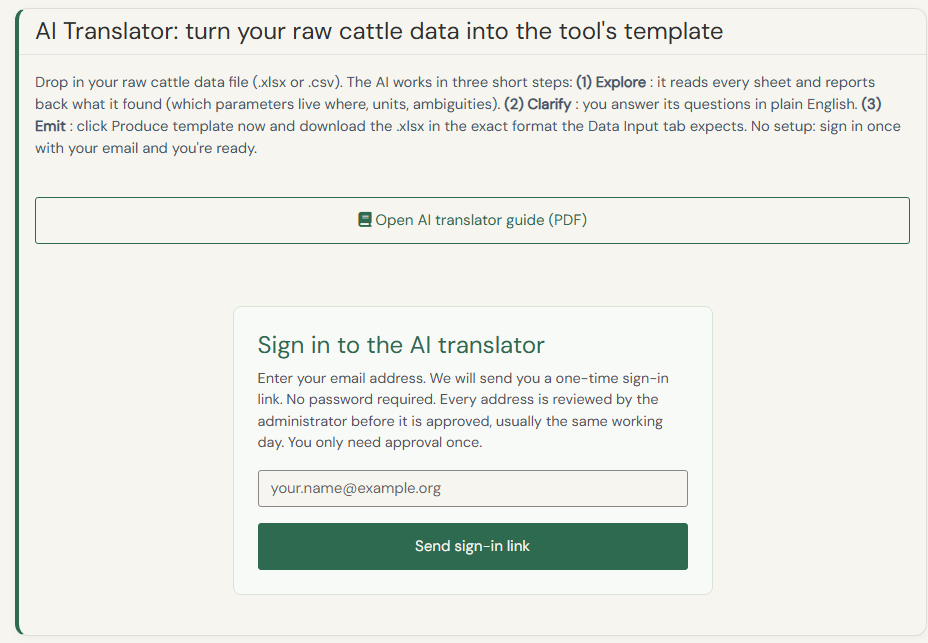

The translator is linked to an AI service and costs money on every run, so we control access. You ask for access with your email address. We review the request and accept your email.

1. Type your email address and click **Send sign-in link**. A confirmation email arrives with a link.
2. Click the link. The first time, the app tells you that your request has been sent to us for approval.
3. When your email is accepted, you receive a second email saying so, with a link to the app.
4. Click that link, or ask for a new sign-in link on the Resources tab. You are redirected to the app with access to the AI translator.

The link in the email is valid for 30 days. Once you have clicked it, the browser stays signed in.

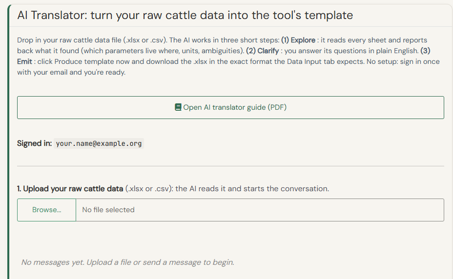

### 2. Uploading the data

The first step is to upload your data. Click the **Browse** button and choose your inventory file. We accept Excel files, with one or several sheets, and CSV files.

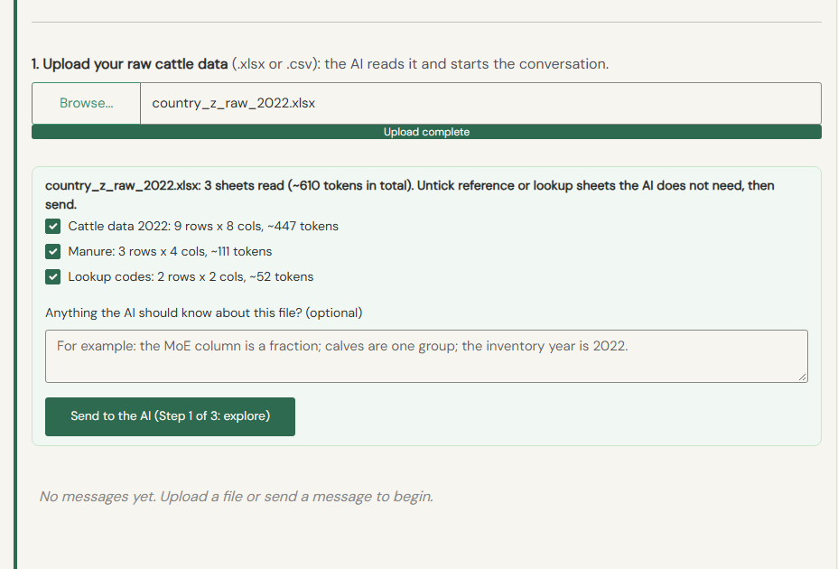

### 3. Data exploration

When the data is uploaded, the first thing the AI does is explore your dataset and understand it: what each label means, what the units are, and where there is an inconsistency or a possible confusion. It then returns a series of questions, to make sure it produces a high-quality dataset.

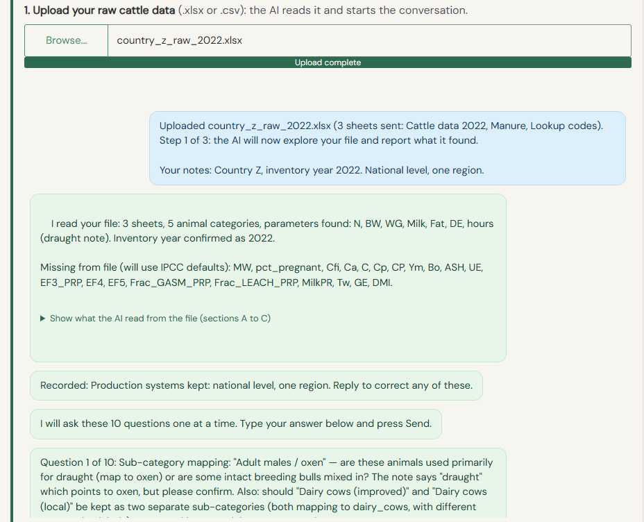

The questions are asked one by one. You answer a question to see the next one.

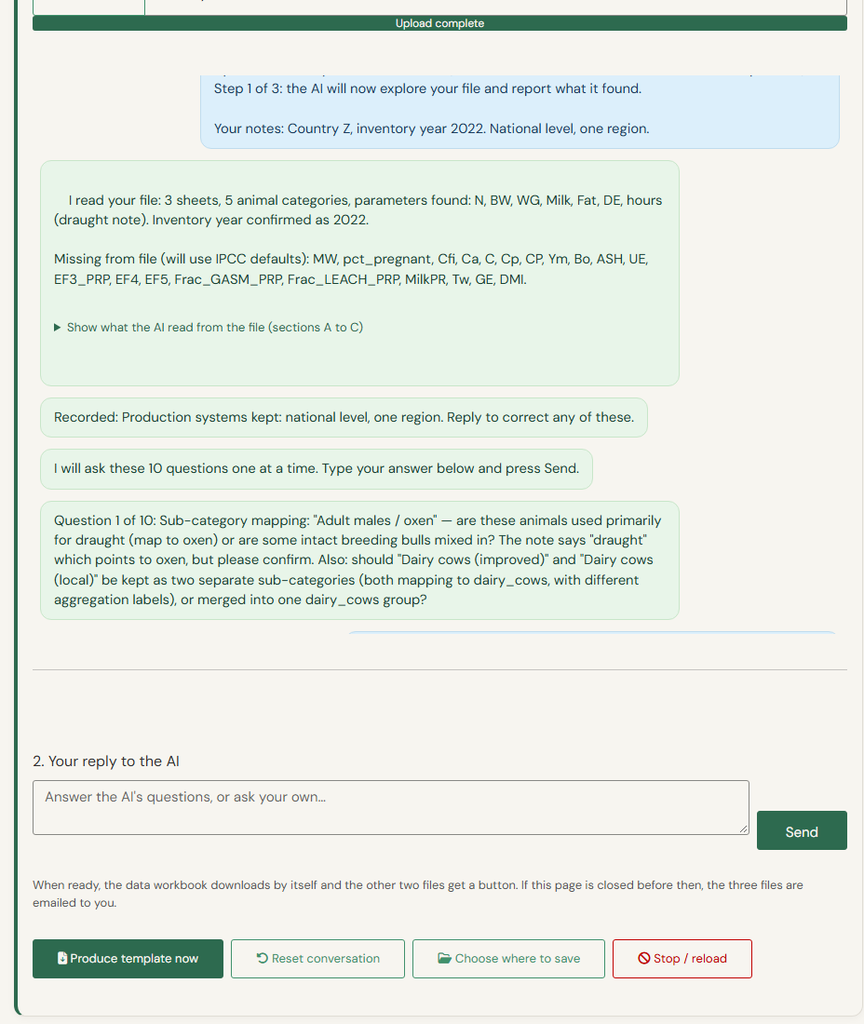

Once all the questions are answered (up to 12), the answers are sent to the AI and it thinks again. It confirms what it has understood from your answers.

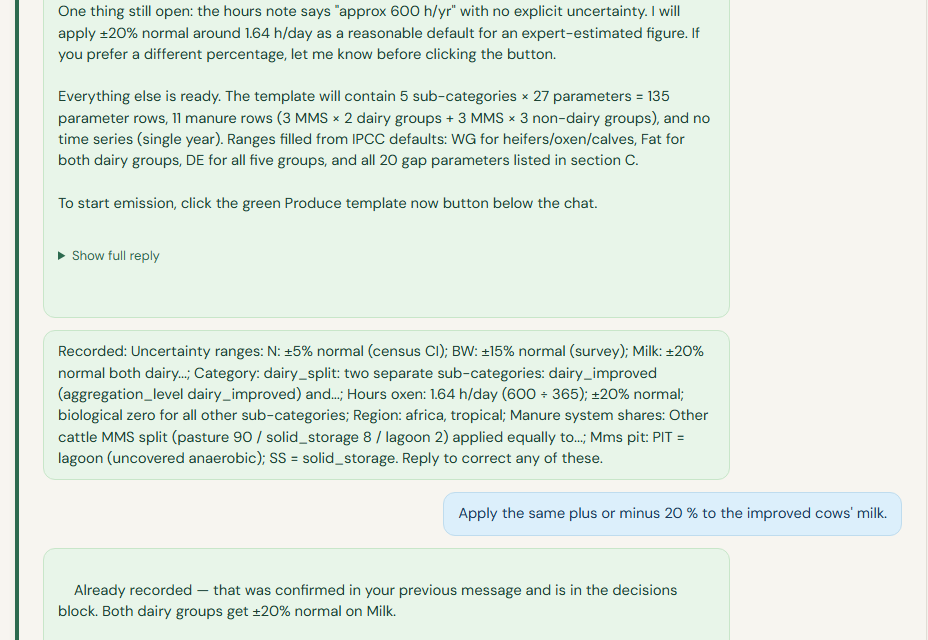

If it still has doubts, it asks other questions, and so on until everything is clear. When nothing is open, the last message of the conversation says that everything is recorded and that the AI’s table of values matches your file, and tells you to click **Produce template now**.

### How to answer the AI’s questions

The AI asks when the file leaves a doubt. Your answer becomes a rule it applies to every row concerned, so:

- **Answer the question, then give the rule.** Not “yes” or “no” alone. Say what the value is, which rows it applies to, and what happens to the other rows.
- **Give numbers and row references** when you have them. “Row 57 is for all groups except calves; calves are row 58.”
- **Say when the file is wrong.** If a value in the file is a known error, give the right value, or say “keep the file’s value, I will correct it afterwards”. The translator never changes a value on its own.
- **Say when you do not know.** “Keep what the file says” is a valid answer. The row stays as it is and the checks list it.

Three examples.

*Question:* “The Milk column is labelled kg/head/day, but a lactation length row exists. Is the value per lactating day or an annual average?” *Weak answer:* “Per lactating day.” *Good answer:* “Per lactating day. Convert it: value × lactation length ÷ 365, with each system’s own length (275, 257, 255, 180 and 254.9 days). Apply the same to every year of the series and to the bounds.”

*Question:* “The MoE sheet gives 0.5, 0.18, 0.177. Are these fractions or percentages?” *Weak answer:* “Fractions.” *Good answer:* “Fractions: 0.5 means a 95 % margin of 50 %. Multiply by 100 everywhere in that sheet. The manure shares are fractions too. pct_pregnant stays a fraction, as the template expects.”

*Question:* “The DE bounds for emergent beef are 56 to 58.4 but the 2024 value is 55.0. Should I adjust a bound?” *Weak answer:* “No.” *Good answer:* “Keep both as written: the value 55.0 and the bounds 56 to 58.4. This is an inconsistency in our file; the check will list it and we will correct the file afterwards.”

### 4. Template production

Once you are happy with the AI’s answers and everything seems clear, click the **Produce template now** button.

A pop-up appears.

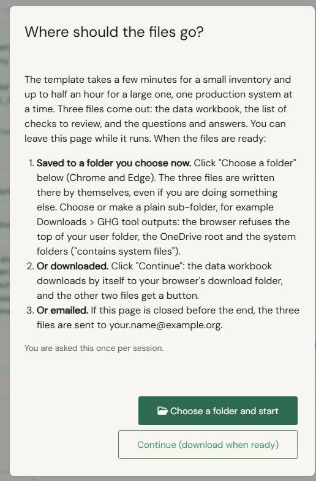

Right now, if nothing happens on the page for about 30 minutes, you are disconnected from the app. The AI is working, but that takes time, so if you are doing something else while the template is being produced, you could be disconnected and lose everything. So you have the option to authorise in advance where the outputs will go: create a folder somewhere, click **Choose a folder and start**, and give the app access to download the files there.

Then the file creation starts. You see a loading bar showing what the AI is doing, with a time estimate. This is a heavy task and can easily take up to 30 minutes. The AI writes one production system at a time; the server then copies every time series from your file’s own rows, runs the checks and writes the files.

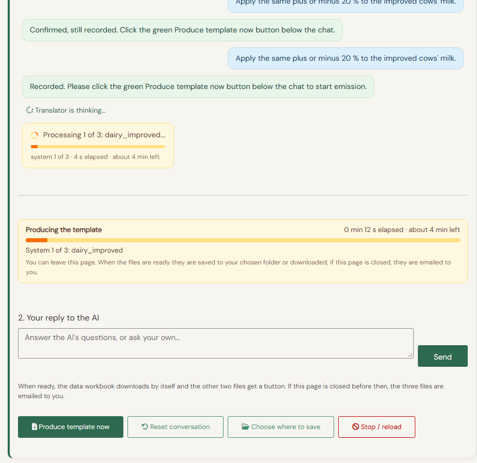

### 5. Outputs

The tool produces three outputs.

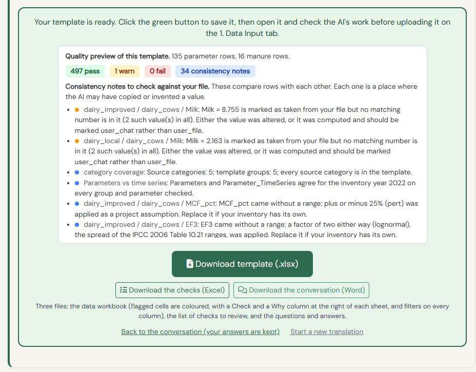

- **The translated template**, in the right format for the tool to run. Its name carries the country, the year and the time, so versions do not get mixed up.
- **The history of the conversation** with the AI, to keep a record of the questions asked and your answers.
- **The checks** you have to do on your data.

### 6. Checks

In the translated template, those cells are highlighted. Each sheet also has a **Check** column and a **Why** column at the right, with filters, so you can show only the cells that need to be checked and read the message. You can also download the list of checks as a separate file.

There are three kinds of checks:

- **Fail**: the value would break or distort the simulation. It has to be corrected before you run the tool.
- **Warn**: the value is unusual or far from the IPCC default. Check it. If it is right, keep a note of why.
- **Info**: a note for information. Nothing to correct.

### 7. Different routes

You can be happy with the translation and go directly to the **1. Data Input** tab to run the calculator.

Or, while checking, you realise that some things are wrong. This can come from the translator, or from the input data itself. Then you can click **Back to the conversation**, give some more information, and the AI produces the template again. You can also start a new conversation from scratch.

Good practice:

- If something is wrong in your input file, change the input file.
- If something is wrong and easy to change in the translated file, change it by hand. There is no need to run the translator again.
- If the problem is more complex, run the translator again, and explain the problem in the context box.

## Privacy

When you upload a file, its contents are sent to the AI service. The connection is encrypted.

The app also keeps a copy of your conversation on its server, with the uploaded data and your email address. This is what lets you close the tab and come back later. The copy is deleted when you click Reset conversation, or when the server restarts after a period without use. There is no other automatic deletion, so if you want it gone, click Reset conversation.

The app also keeps a small usage log: the date, your email address, the AI model used and the size of each request. It does not contain your data. It is only there so the administrator can keep an eye on the cost.

The AI service has its own terms for the data it receives.